# Introduction

Now lets see if there's a correlation between the varroa mites and colony loss. If there is a correlation, we would expect to see that the periods of times where the varroa mites population is higher, the percentage in colony loss is higher as well.

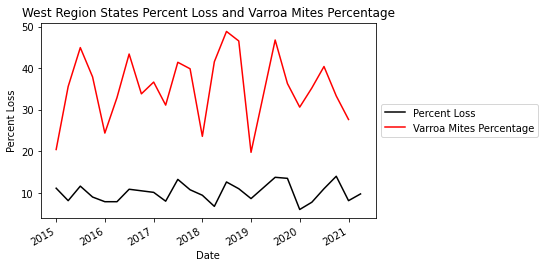

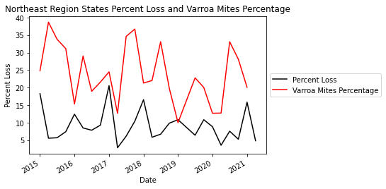

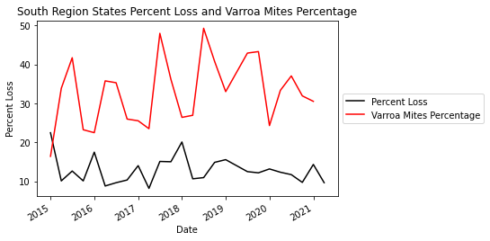

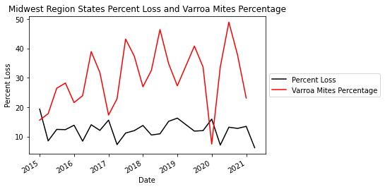

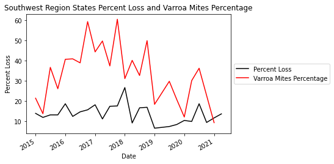

```python
# Combining percent loss and stressor graphs
# Western
w = stress_w.drop(['Other pests and parasites (Percent)', 'Diseases (percent)', 'Pesticides (percent)', 'Other (percent)',
                  'Unknown (percent)'], axis = 1)
bee_col_loss_w.groupby(['Date']).mean().plot(color="black", legend=False)
plt.plot(w, color = "red", label = "Varroa Mites Percentage")
plt.ylabel("Percent Loss")
plt.title("West Region States Percent Loss and Varroa Mites Percentage")
plt.legend(loc='center left', bbox_to_anchor=(1.0, 0.5))
plt.show()

# Northeast
ne = stress_ne.drop(['Other pests and parasites (Percent)', 'Diseases (percent)', 'Pesticides (percent)', 'Other (percent)',
                  'Unknown (percent)'], axis = 1)
bee_col_loss_ne.groupby(['Date']).mean().plot(color="black", legend=False)
plt.plot(ne, color = "red", label = "Varroa Mites Percentage")
plt.ylabel("Percent Loss")
plt.title("Northeast Region States Percent Loss and Varroa Mites Percentage")
plt.legend(loc='center left', bbox_to_anchor=(1.0, 0.5))
plt.show()

# South
s = stress_s.drop(['Other pests and parasites (Percent)', 'Diseases (percent)', 'Pesticides (percent)', 'Other (percent)',
                  'Unknown (percent)'], axis = 1)
bee_col_loss_s.groupby(['Date']).mean().plot(color="black", legend=False)
plt.plot(s, color = "red", label = "Varroa Mites Percentage")
plt.ylabel("Percent Loss")
plt.title("South Region States Percent Loss and Varroa Mites Percentage")
plt.legend(loc='center left', bbox_to_anchor=(1.0, 0.5))
plt.show()

# Midwest
mw = stress_mw.drop(['Other pests and parasites (Percent)', 'Diseases (percent)', 'Pesticides (percent)', 'Other (percent)',
                  'Unknown (percent)'], axis = 1)
bee_col_loss_mw.groupby(['Date']).mean().plot(color="black", legend=False)
plt.plot(mw, color = "red", label = "Varroa Mites Percentage")
plt.ylabel("Percent Loss")
plt.title("Midwest Region States Percent Loss and Varroa Mites Percentage")
plt.legend(loc='center left', bbox_to_anchor=(1.0, 0.5))
plt.show()

# Southwest
sw = stress_sw.drop(['Other pests and parasites (Percent)', 'Diseases (percent)', 'Pesticides (percent)', 'Other (percent)',
                  'Unknown (percent)'], axis = 1)
bee_col_loss_sw.groupby(['Date']).mean().plot(color="black", legend=False)
plt.plot(sw, color = "red", label = "Varroa Mites Percentage")
plt.ylabel("Percent Loss")
plt.title("Southwest Region States Percent Loss and Varroa Mites Percentage")
plt.legend(loc='center left', bbox_to_anchor=(1.0, 0.5))
plt.show()
```

Visually some of the graphs seem to slighty follow the varroa mites' percentage though it's difficult to draw a correlation between the mites' population vs. the percent loss when other factors such as seasons, diseases, and pesticides also contribute to the percent loss. So it may be more useful to find direct correlations between each factor vs. percent loss for each region.

```python
# Calling correlation between each stressor column and the percent loss column for each regional dataset.
# West
print("West Regions:")
print("Varroa Mites vs Percent Loss: " + str(bee_stress_w['Varroa Mites (Percent)']. corr(bee_col_loss_w['Percent Loss'])))
print("Other vs Percent Loss: " + str(bee_stress_w['Other pests and parasites (Percent)']. corr(bee_col_loss_w['Percent Loss'])))
print("Disease vs Percent Loss: " + str(bee_stress_w['Diseases (percent)']. corr(bee_col_loss_w['Percent Loss'])))
print("Pesticides vs Percent Loss: " + str(bee_stress_w['Pesticides (percent)']. corr(bee_col_loss_w['Percent Loss'])))
print("Other vs Percent Loss: " + str(bee_stress_w['Other (percent)']. corr(bee_col_loss_w['Percent Loss'])))
print("Unknown vs Percent Loss: " + str(bee_stress_w['Unknown (percent)']. corr(bee_col_loss_w['Percent Loss'])))

# Northeast
print("\nNortheast Regions:")
print("Varroa Mites vs Percent Loss: " + str(bee_stress_ne['Varroa Mites (Percent)']. corr(bee_col_loss_ne['Percent Loss'])))
print("Other vs Percent Loss: " + str(bee_stress_ne['Other pests and parasites (Percent)']. corr(bee_col_loss_ne['Percent Loss'])))
print("Disease vs Percent Loss: " + str(bee_stress_ne['Diseases (percent)']. corr(bee_col_loss_ne['Percent Loss'])))
print("Pesticides vs Percent Loss: " + str(bee_stress_ne['Pesticides (percent)']. corr(bee_col_loss_ne['Percent Loss'])))
print("Other vs Percent Loss: " + str(bee_stress_ne['Other (percent)']. corr(bee_col_loss_ne['Percent Loss'])))
print("Unknown vs Percent Loss: " + str(bee_stress_ne['Unknown (percent)']. corr(bee_col_loss_ne['Percent Loss'])))

# South
print("\nSouth Regions:")
print("Varroa Mites vs Percent Loss: " + str(bee_stress_s['Varroa Mites (Percent)']. corr(bee_col_loss_s['Percent Loss'])))
print("Other vs Percent Loss: " + str(bee_stress_s['Other pests and parasites (Percent)']. corr(bee_col_loss_s['Percent Loss'])))
print("Disease vs Percent Loss: " + str(bee_stress_s['Diseases (percent)']. corr(bee_col_loss_s['Percent Loss'])))
print("Pesticides vs Percent Loss: " + str(bee_stress_s['Pesticides (percent)']. corr(bee_col_loss_s['Percent Loss'])))
print("Other vs Percent Loss: " + str(bee_stress_s['Other (percent)']. corr(bee_col_loss_s['Percent Loss'])))
print("Unknown vs Percent Loss: " + str(bee_stress_s['Unknown (percent)']. corr(bee_col_loss_s['Percent Loss'])))

# Midwest
print("\nMidwest Regions:")
print("Varroa Mites vs Percent Loss: " + str(bee_stress_mw['Varroa Mites (Percent)']. corr(bee_col_loss_mw['Percent Loss'])))
print("Other vs Percent Loss: " + str(bee_stress_mw['Other pests and parasites (Percent)']. corr(bee_col_loss_mw['Percent Loss'])))
print("Disease vs Percent Loss: " + str(bee_stress_mw['Diseases (percent)']. corr(bee_col_loss_mw['Percent Loss'])))
print("Pesticides vs Percent Loss: " + str(bee_stress_mw['Pesticides (percent)']. corr(bee_col_loss_mw['Percent Loss'])))
print("Other vs Percent Loss: " + str(bee_stress_mw['Other (percent)']. corr(bee_col_loss_mw['Percent Loss'])))
print("Unknown vs Percent Loss: " + str(bee_stress_mw['Unknown (percent)']. corr(bee_col_loss_mw['Percent Loss'])))

# Southwest
print("\nSouthwest Regions:")
print("Varroa Mites vs Percent Loss: " + str(bee_stress_sw['Varroa Mites (Percent)']. corr(bee_col_loss_sw['Percent Loss'])))
print("Other vs Percent Loss: " + str(bee_stress_sw['Other pests and parasites (Percent)']. corr(bee_col_loss_sw['Percent Loss'])))
print("Disease vs Percent Loss: " + str(bee_stress_sw['Diseases (percent)']. corr(bee_col_loss_sw['Percent Loss'])))
print("Pesticides vs Percent Loss: " + str(bee_stress_sw['Pesticides (percent)']. corr(bee_col_loss_sw['Percent Loss'])))
print("Other vs Percent Loss: " + str(bee_stress_sw['Other (percent)']. corr(bee_col_loss_sw['Percent Loss'])))
print("Unknown vs Percent Loss: " + str(bee_stress_sw['Unknown (percent)']. corr(bee_col_loss_sw['Percent Loss'])))
```

```
West Regions:
Varroa Mites vs Percent Loss: 0.213284823511124
Other vs Percent Loss: 0.027908076899705276
Disease vs Percent Loss: 0.053266687717465115
Pesticides vs Percent Loss: 0.24508399326326635
Other vs Percent Loss: 0.10124156376332168
Unknown vs Percent Loss: 0.05187856002011999

Northeast Regions:
Varroa Mites vs Percent Loss: 0.20812998943801614
Other vs Percent Loss: -0.011879586725027074
Disease vs Percent Loss: 0.10924841992742865
Pesticides vs Percent Loss: 0.005278374317411241
Other vs Percent Loss: 0.4523495526591124
Unknown vs Percent Loss: 0.38979772499602977

South Regions:
Varroa Mites vs Percent Loss: 0.12248951166707388
Other vs Percent Loss: 0.07730875226675259
Disease vs Percent Loss: 0.021473150808586482
Pesticides vs Percent Loss: 0.09014787645291085
Other vs Percent Loss: 0.29614546031232547
Unknown vs Percent Loss: 0.24515243775336976

Midwest Regions:
Varroa Mites vs Percent Loss: 0.21636108308461027
Other vs Percent Loss: 0.13993920221746828
Disease vs Percent Loss: 0.10124528030245565
Pesticides vs Percent Loss: 0.16988252268865547
Other vs Percent Loss: 0.34927563864628025
Unknown vs Percent Loss: 0.19475965701327505

Southwest Regions:
Varroa Mites vs Percent Loss: 0.5955632472027468
Other vs Percent Loss: -0.05917786817334429
Disease vs Percent Loss: 0.3598222971893357
Pesticides vs Percent Loss: 0.0770281835320203
Other vs Percent Loss: 0.24414463019614246
Unknown vs Percent Loss: 0.13363767155606052
```

```
Western Region Other Stressor:
Average Other Factor in spring: Other (percent)    7.644372
dtype: float64
Average Other Factor in winter: Other (percent)    5.654002
dtype: float64
```

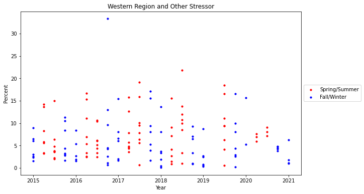

```
Northeastern Region Other Stressor:
Average Other Factor in spring: Other (percent)    3.648528
dtype: float64
Average Other Factor in winte: Other (percent)    4.569121
dtype: float64
```

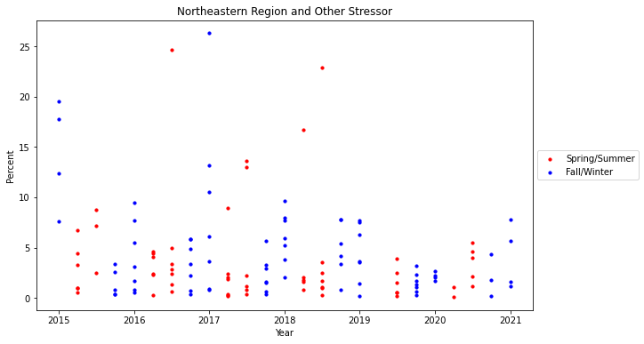

```
South Region Other Stressor:
Average Other Factor in spring: Other (percent)    7.001097
dtype: float64
Average Other Factor in winte: Other (percent)    6.464393
dtype: float64
```

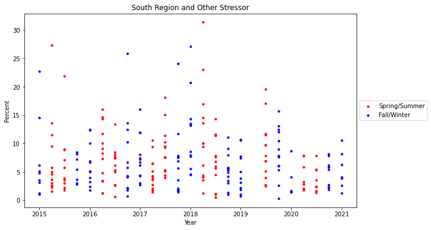

```
Midwestern Region Other Stressor:
Average Other Factor in spring: Other (percent)    8.946901
dtype: float64
Average Other Factor in winte: Other (percent)    7.547925
dtype: float64
```

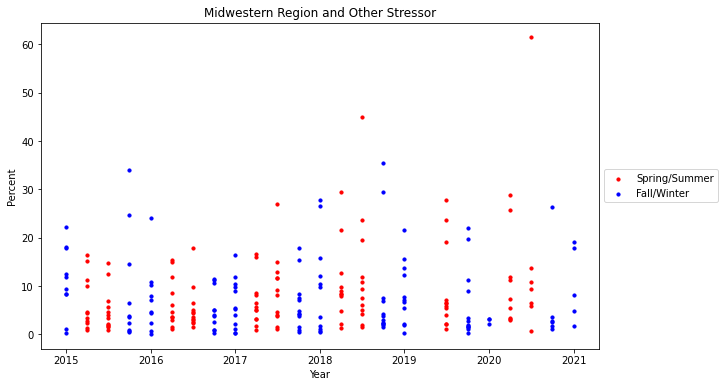

```
Southwest Region Other Stressor:
Average Other Factor in spring: Other (percent)    9.665909
dtype: float64
Average Other Factor in winte: Other (percent)    4.097222
dtype: float64
```

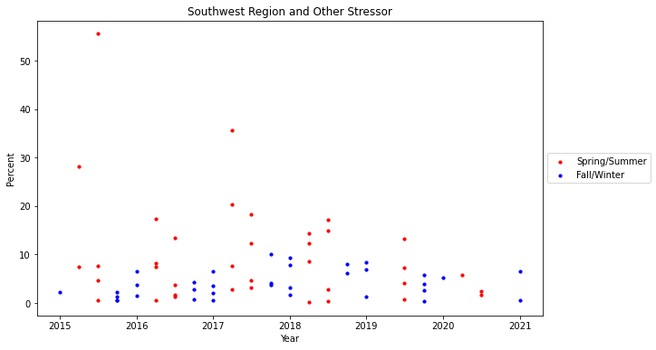

```python
# Creating new datasets with only the spring/summer months and fall/winter months for each region
# West
w = bee_stress_w.drop(['Other pests and parasites (Percent)', 'Diseases (percent)', 'Pesticides (percent)', 'Unknown (percent)', 'Varroa Mites (Percent)'], axis = 1)
s_spr_sum_w = w[(w.Date.dt.month == 4) | (w.Date.dt.month == 7)]
s_fal_win_w = w[(w.Date.dt.month == 1) | (w.Date.dt.month == 10)]

# Northeast
ne = bee_stress_ne.drop(['Other pests and parasites (Percent)', 'Diseases (percent)', 'Pesticides (percent)', 'Unknown (percent)', 'Varroa Mites (Percent)'], axis = 1)
s_spr_sum_ne = ne[(ne.Date.dt.month == 4) | (ne.Date.dt.month == 7)]
s_fal_win_ne = ne[(ne.Date.dt.month == 1) | (ne.Date.dt.month == 10)]

# Southern
s = bee_stress_s.drop(['Other pests and parasites (Percent)', 'Diseases (percent)', 'Pesticides (percent)', 'Unknown (percent)', 'Varroa Mites (Percent)'], axis = 1)
s_spr_sum_s = s[(s.Date.dt.month == 4) | (s.Date.dt.month == 7)]
s_fal_win_s = s[(s.Date.dt.month == 1) | (s.Date.dt.month == 10)]

# Midwest
mw = bee_stress_mw.drop(['Other pests and parasites (Percent)', 'Diseases (percent)', 'Pesticides (percent)', 'Unknown (percent)', 'Varroa Mites (Percent)'], axis = 1)
s_spr_sum_mw = mw[(mw.Date.dt.month == 4) | (mw.Date.dt.month == 7)]
s_fal_win_mw = mw[(mw.Date.dt.month == 1) | (mw.Date.dt.month == 10)]

# Southwest
sw = bee_stress_sw.drop(['Other pests and parasites (Percent)', 'Diseases (percent)', 'Pesticides (percent)', 'Unknown (percent)', 'Varroa Mites (Percent)'], axis = 1)
s_spr_sum_sw = sw[(sw.Date.dt.month == 4) | (sw.Date.dt.month == 7)]
s_fal_win_sw = sw[(sw.Date.dt.month == 1) | (sw.Date.dt.month == 10)]

# Create a scatter plot to see the distributions of the Other stressor to check for correlation between seasons
# West
print("Western Region Other Stressor:")
print("Average Other Factor in spring: " + str(s_spr_sum_w.groupby(['Date']).mean().mean()))
print("Average Other Factor in winter: " + str(s_fal_win_w.groupby(['Date']).mean().mean()))
fig = plt.figure(figsize=(10, 6))
ax1 = fig.add_subplot(111)
ax1.scatter(s_spr_sum_w['Date'], s_spr_sum_w['Other (percent)'], s=10, c='r', label='Spring/Summer')
ax1.scatter(s_fal_win_w['Date'], s_fal_win_w['Other (percent)'], s=10, c='b', label='Fall/Winter')
plt.ylabel("Percent")
plt.xlabel("Year")
plt.title("Western Region and Other Stressor")
plt.legend(loc='center left', bbox_to_anchor=(1.0, 0.5))
plt.show()

# Northeast
print("Northeastern Region Other Stressor:")
print("Average Other Factor in spring: " + str(s_spr_sum_ne.groupby(['Date']).mean().mean()))
print("Average Other Factor in winter: " + str(s_fal_win_ne.groupby(['Date']).mean().mean()))
fig = plt.figure(figsize=(10, 6))
ax1 = fig.add_subplot(111)
ax1.scatter(s_spr_sum_ne['Date'], s_spr_sum_ne['Other (percent)'], s=10, c='r', label='Spring/Summer')
ax1.scatter(s_fal_win_ne['Date'], s_fal_win_ne['Other (percent)'], s=10, c='b', label='Fall/Winter')
plt.ylabel("Percent")
plt.xlabel("Year")
plt.title("Northeastern Region and Other Stressor")
plt.legend(loc='center left', bbox_to_anchor=(1.0, 0.5))
plt.show()

# South
print("South Region Other Stressor:")
print("Average Other Factor in spring: " + str(s_spr_sum_s.groupby(['Date']).mean().mean()))
print("Average Other Factor in winter: " + str(s_fal_win_s.groupby(['Date']).mean().mean()))
fig = plt.figure(figsize=(10, 6))
ax1 = fig.add_subplot(111)
ax1.scatter(s_spr_sum_s['Date'], s_spr_sum_s['Other (percent)'], s=10, c='r', label='Spring/Summer')
ax1.scatter(s_fal_win_s['Date'], s_fal_win_s['Other (percent)'], s=10, c='b', label='Fall/Winter')
plt.ylabel("Percent")
plt.xlabel("Year")
plt.title("South Region and Other Stressor")
plt.legend(loc='center left', bbox_to_anchor=(1.0, 0.5))
plt.show()

# Midwest
print("Midwestern Region Other Stressor:")
print("Average Other Factor in spring: " + str(s_spr_sum_mw.groupby(['Date']).mean().mean()))
print("Average Other Factor in winter: " + str(s_fal_win_mw.groupby(['Date']).mean().mean()))
fig = plt.figure(figsize=(10, 6))
ax1 = fig.add_subplot(111)
ax1.scatter(s_spr_sum_mw['Date'], s_spr_sum_mw['Other (percent)'], s=10, c='r', label='Spring/Summer')
ax1.scatter(s_fal_win_mw['Date'], s_fal_win_mw['Other (percent)'], s=10, c='b', label='Fall/Winter')
plt.ylabel("Percent")
plt.xlabel("Year")
plt.title("Midwestern Region and Other Stressor")
plt.legend(loc='center left', bbox_to_anchor=(1.0, 0.5))
plt.show()

# Southwest
print("Southwest Region Other Stressor:")
print("Average Other Factor in spring: " + str(s_spr_sum_sw.groupby(['Date']).mean().mean()))
print("Average Other Factor in winter: " + str(s_fal_win_sw.groupby(['Date']).mean().mean()))
fig = plt.figure(figsize=(10, 6))
ax1 = fig.add_subplot(111)
ax1.scatter(s_spr_sum_sw['Date'], s_spr_sum_sw['Other (percent)'], s=10, c='r', label='Spring/Summer')
ax1.scatter(s_fal_win_sw['Date'], s_fal_win_sw['Other (percent)'], s=10, c='b', label='Fall/Winter')
plt.ylabel("Percent")
plt.xlabel("Year")
plt.title("Southwest Region and Other Stressor")
plt.legend(loc='center left', bbox_to_anchor=(1.0, 0.5))
plt.show()
```

Based on the means of the seasonal datasets, only the Southwest has a significant increase in the average percentage of the other factor during the spring. For all of the datasets except the Northeast, the average percentage of the other factor slightly increases in the spring. Since bees become productive during the spring, the factor of climate can be ruled out as a major influencer on the 'other factor' label.

# Hypothesis Testing

To test some hypotheses, the statsmodels libraries needs to be imported to use the linear regression model. The model can vertify if there's a moderate relationship between a region and certain stressors. The datasets also need to be prepped for the model such that all the states/dates in the dataset has an associated percentage for a certain stressor as well as a percent loss in colonies.

```python
import statsmodels.api as sm
from sklearn import linear_model
```

```python
# Resets bee stressor region datasets with states
bee_stress_w = bee_stress[(bee_stress['State'] == 'California') | (bee_stress['State'] == 'Nevada') | (bee_stress['State'] == 'Utah') | (bee_stress['State'] == 'Colorado') | (bee_stress['State'] == 'Wyoming') | (bee_stress['State'] == 'Idaho') | (bee_stress['State'] == 'Montana') | (bee_stress['State'] == 'Washington') | (bee_stress['State'] == 'Oregon') | (bee_stress['State'] == 'Alaska')]
bee_stress_ne = bee_stress[(bee_stress['State'] == 'Massachusetts') | (bee_stress['State'] == 'Rhode Island') | (bee_stress['State'] == 'Connecticut') | (bee_stress['State'] == 'Vermont') | (bee_stress['State'] == 'New Hampshire') | (bee_stress['State'] == 'Maine') | (bee_stress['State'] == 'Pennsylvania') | (bee_stress['State'] == 'New Jersey') | (bee_stress['State'] == 'New York')]
bee_stress_s = bee_stress[(bee_stress['State'] == 'Louisiana') | (bee_stress['State'] == 'Arkansas') | (bee_stress['State'] == 'Mississippi') | (bee_stress['State'] == 'Alabama') | (bee_stress['State'] == 'Georgia') | (bee_stress['State'] == 'Florida') | (bee_stress['State'] == 'South Carolina') | (bee_stress['State'] == 'North Carolina') | (bee_stress['State'] == 'Tennessee') | (bee_stress['State'] == 'Kentucky') | (bee_stress['State'] == 'Virginia') | (bee_stress['State'] == 'West Virginia') | (bee_stress['State'] == 'Maryland') | (bee_stress['State'] == 'Delaware')]
bee_stress_mw = bee_stress[(bee_stress['State'] == 'North Dakota') | (bee_stress['State'] == 'South Dakota') | (bee_stress['State'] == 'Nebraska') | (bee_stress['State'] == 'Kansas') | (bee_stress['State'] == 'Missouri') | (bee_stress['State'] == 'Iowa') | (bee_stress['State'] == 'Minnesota') | (bee_stress['State'] == 'Wisconsin') | (bee_stress['State'] == 'Illinois') | (bee_stress['State'] == 'Indiana') | (bee_stress['State'] == 'Michigan') | (bee_stress['State'] == 'Ohio')]
bee_stress_sw = bee_stress[(bee_stress['State'] == 'Arizona') | (bee_stress['State'] == 'New Mexico') | (bee_stress['State'] == 'Texas') | (bee_stress['State'] == 'Oklahoma')]

# Merging the percent loss regional dataset with its regional stressor data
# West
w_final = bee_stress_w.merge(bee_col_loss_w, on=['Date', 'State'],how='outer')
w_final = w_final.dropna()

# Northeast
ne_final = bee_stress_ne.merge(bee_col_loss_ne, on=['Date', 'State'],how='outer')
ne_final = ne_final.dropna()

# South
s_final = bee_stress_s.merge(bee_col_loss_s, on=['Date', 'State'],how='outer')
s_final = s_final.dropna()

# Midwest
mw_final = bee_stress_mw.merge(bee_col_loss_mw, on=['Date', 'State'],how='outer')
mw_final = mw_final.dropna()

# Southwest
sw_final = bee_stress_sw.merge(bee_col_loss_sw, on=['Date', 'State'],how='outer')
sw_final = sw_final.dropna()

# Checking datasets for correct merge
w_final
ne_final
s_final
mw_final
sw_final
```

|  | State | Varroa Mites (Percent) | Other pests and parasites (Percent) | Diseases (percent) | Pesticides (percent) | Other (percent) | Unknown (percent) | Date | Percent Loss |
| --- | --- | --- | --- | --- | --- | --- | --- | --- | --- |
| 0 | Texas | 21.5 | 12.2 | 5.0 | 11.1 | 2.3 | 6.2 | 2015-01-01 | 10.0 |
| 1 | Arizona | 8.4 | 32.1 | 0.5 | 20.1 | 28.2 | 0.3 | 2015-04-01 | 17.0 |
| 2 | Texas | 19.3 | 22.9 | 2.5 | 6.6 | 7.4 | 3.0 | 2015-04-01 | 11.0 |
| 3 | Arizona | 53.5 | 24.8 | 5.4 | 17.3 | 7.6 | 5.1 | 2015-07-01 | 15.0 |
| 4 | New Mexico | 61.2 | 55.0 | 55.0 | 58.0 | 55.5 | 0.7 | 2015-07-01 | 25.0 |
| ... | ... | ... | ... | ... | ... | ... | ... | ... | ... |
| 66 | Texas | 30.2 | 7.7 | 3.3 | 4.6 | 5.7 | 5.8 | 2020-04-01 | 9.0 |
| 67 | Oklahoma | 52.4 | 8.0 | 0.9 | 1.7 | 2.4 | 0.8 | 2020-07-01 | 14.0 |
| 68 | Texas | 20.2 | 13.6 | 2.0 | 6.7 | 1.6 | 0.6 | 2020-07-01 | 5.0 |
| 69 | Arizona | 4.6 | 5.9 | 5.9 | 0.0 | 0.5 | 4.2 | 2021-01-01 | 24.0 |
| 70 | New Mexico | 14.2 | 0.1 | 0.0 | 0.0 | 6.5 | 1.9 | 2021-01-01 | 7.0 |

71 rows × 9 columns

For the West region, during the data exploration the region's highest stressor was varroa mites. We can test if varroa mites were part of the main contributer to the percent loss of Western bee colonies. The null hypothesis is that varroa mites have no affect on the percent loss at all.

```python
# Performing linear regression on the West region dataset
# Set x to be all the stressors and y to be percent loss
x = w_final[['Varroa Mites (Percent)','Other pests and parasites (Percent)', 'Diseases (percent)', 'Pesticides (percent)', 'Other (percent)', 'Unknown (percent)']]
y = w_final['Percent Loss']

# Get the linear regression model's intercept and coefficients
regr = linear_model.LinearRegression()
regr.fit(x, y)

print('Intercept: \n', regr.intercept_)
print('Coefficients: \n', regr.coef_)

# Fit linear regression model
x = sm.add_constant(x)
model = sm.OLS(y, x).fit()
predictions = model.predict(x)

# Shows summary
model.summary()
```

```
Intercept:
 8.079963565642267
Coefficients:
 [ 0.05122492 -0.08699162 -0.02480836  0.15873622 -0.00422964  0.09306219]
```

OLS Regression Results

| Dep. Variable: | Percent Loss | R-squared: | 0.093 |
| --- | --- | --- | --- |
| Model: | OLS | Adj. R-squared: | 0.056 |
| Method: | Least Squares | F-statistic: | 2.523 |
| Date: | Fri, 16 Dec 2022 | Prob (F-statistic): | 0.0236 |
| Time: | 20:32:45 | Log-Likelihood: | -451.87 |
| No. Observations: | 154 | AIC: | 917.7 |
| Df Residuals: | 147 | BIC: | 939.0 |
| Df Model: | 6 |  |  |
| Covariance Type: | nonrobust |  |  |

|  | coef | std err | t | P>\|t\| | [0.025 | 0.975] |
| --- | --- | --- | --- | --- | --- | --- |
| const | 8.0800 | 0.977 | 8.271 | 0.000 | 6.149 | 10.010 |
| Varroa Mites (Percent) | 0.0512 | 0.029 | 1.755 | 0.081 | -0.006 | 0.109 |
| Other pests and parasites (Percent) | -0.0870 | 0.067 | -1.305 | 0.194 | -0.219 | 0.045 |
| Diseases (percent) | -0.0248 | 0.076 | -0.327 | 0.744 | -0.175 | 0.125 |
| Pesticides (percent) | 0.1587 | 0.064 | 2.482 | 0.014 | 0.032 | 0.285 |
| Other (percent) | -0.0042 | 0.088 | -0.048 | 0.962 | -0.178 | 0.170 |
| Unknown (percent) | 0.0931 | 0.101 | 0.924 | 0.357 | -0.106 | 0.292 |

| Omnibus: | 15.713 | Durbin-Watson: | 1.881 |
| --- | --- | --- | --- |
| Prob(Omnibus): | 0.000 | Jarque-Bera (JB): | 17.483 |
| Skew: | 0.734 | Prob(JB): | 0.000160 |
| Kurtosis: | 3.756 | Cond. No. | 111. |

Notes:  
[1] Standard Errors assume that the covariance matrix of the errors is correctly specified.

Based on the p values, almost all of the region's stressors with the exception of pesticides do not have a relationship with region's percent loss due to their p values passing 0.05. The R-squared value is also low, meaning that the stressors offer little to no explanation for the variation in the west regions' percent loss.

For the Northeast region, during the data exploration the region's highest stressor was the others category. My hypothesis is that the other factors were an influence on the percent loss of Northeastern bee colonies. The null hypothesis is that the other factors have no affect on the percent loss at all.

```python
# Performing linear regression on the Northeast region dataset
# Set x to be all the stressors and y to be percent loss
x = ne_final[['Varroa Mites (Percent)','Other pests and parasites (Percent)', 'Diseases (percent)', 'Pesticides (percent)', 'Other (percent)', 'Unknown (percent)']]
y = ne_final['Percent Loss']

# Get the linear regression model's intercept and coefficients
regr = linear_model.LinearRegression()
regr.fit(x, y)

print('Intercept: \n', regr.intercept_)
print('Coefficients: \n', regr.coef_)

# Fit linear regression model
x = sm.add_constant(x)
model = sm.OLS(y, x).fit()
predictions = model.predict(x)

# Shows summary
model.summary()
```

```
Intercept:
 4.807687493974254
Coefficients:
 [ 0.08265544 -0.13176462 -0.09259678 -0.03307575  0.66114823  0.46125881]
```

OLS Regression Results

| Dep. Variable: | Percent Loss | R-squared: | 0.332 |
| --- | --- | --- | --- |
| Model: | OLS | Adj. R-squared: | 0.301 |
| Method: | Least Squares | F-statistic: | 10.54 |
| Date: | Fri, 16 Dec 2022 | Prob (F-statistic): | 1.80e-09 |
| Time: | 20:32:45 | Log-Likelihood: | -430.02 |
| No. Observations: | 134 | AIC: | 874.0 |
| Df Residuals: | 127 | BIC: | 894.3 |
| Df Model: | 6 |  |  |
| Covariance Type: | nonrobust |  |  |

|  | coef | std err | t | P>\|t\| | [0.025 | 0.975] |
| --- | --- | --- | --- | --- | --- | --- |
| const | 4.8077 | 1.020 | 4.712 | 0.000 | 2.788 | 6.827 |
| Varroa Mites (Percent) | 0.0827 | 0.041 | 2.023 | 0.045 | 0.002 | 0.163 |
| Other pests and parasites (Percent) | -0.1318 | 0.109 | -1.206 | 0.230 | -0.348 | 0.084 |
| Diseases (percent) | -0.0926 | 0.119 | -0.779 | 0.437 | -0.328 | 0.143 |
| Pesticides (percent) | -0.0331 | 0.101 | -0.327 | 0.744 | -0.233 | 0.167 |
| Other (percent) | 0.6611 | 0.128 | 5.177 | 0.000 | 0.408 | 0.914 |
| Unknown (percent) | 0.4613 | 0.140 | 3.290 | 0.001 | 0.184 | 0.739 |

| Omnibus: | 36.403 | Durbin-Watson: | 1.696 |
| --- | --- | --- | --- |
| Prob(Omnibus): | 0.000 | Jarque-Bera (JB): | 89.392 |
| Skew: | 1.073 | Prob(JB): | 3.88e-20 |
| Kurtosis: | 6.377 | Cond. No. | 62.5 |

Notes:  
[1] Standard Errors assume that the covariance matrix of the errors is correctly specified.

Based on the model my hypothesis was proven correct as there does seem to be a relationship between the other factors and the region's percent loss since it's less than 0.05. The null hypothesis is rejected. Varroa mites and the unknown category also has a relationship with the percent loss of the region as well. Based on the R-squared value, 33.2% of the percent loss variation has a correlation with the percentage of mites, other factors, and unknown factors.

For the South I had noted that its highest correlated stressor was the other factors too, but the regions' percent loss was also influenced by the seasons as seen during the data exploration. My hypothesis for the South region is that there is a relationship between the other factors and the percent loss. The null hypothesis is that there is no relationship between the two variables at all.

```python
# Performing linear regression on the South region dataset
# Set x to be all the stressors and y to be percent loss
x = s_final[['Varroa Mites (Percent)','Other pests and parasites (Percent)', 'Diseases (percent)', 'Pesticides (percent)', 'Other (percent)', 'Unknown (percent)']]
y = s_final['Percent Loss']

# Get the linear regression model's intercept and coefficients
regr = linear_model.LinearRegression()
regr.fit(x, y)

print('Intercept: \n', regr.intercept_)
print('Coefficients: \n', regr.coef_)

# Fit linear regression model
x = sm.add_constant(x)
model = sm.OLS(y, x).fit()
predictions = model.predict(x)

# Shows summary
model.summary()
```

```
Intercept:
 9.011841991131009
Coefficients:
 [ 0.0244612  -0.02414531 -0.03662722  0.00220914  0.3323734   0.24555697]
```

OLS Regression Results

| Dep. Variable: | Percent Loss | R-squared: | 0.134 |
| --- | --- | --- | --- |
| Model: | OLS | Adj. R-squared: | 0.114 |
| Method: | Least Squares | F-statistic: | 6.525 |
| Date: | Fri, 16 Dec 2022 | Prob (F-statistic): | 2.04e-06 |
| Time: | 20:32:45 | Log-Likelihood: | -836.60 |
| No. Observations: | 259 | AIC: | 1687. |
| Df Residuals: | 252 | BIC: | 1712. |
| Df Model: | 6 |  |  |
| Covariance Type: | nonrobust |  |  |

|  | coef | std err | t | P>\|t\| | [0.025 | 0.975] |
| --- | --- | --- | --- | --- | --- | --- |
| const | 9.0118 | 0.949 | 9.500 | 0.000 | 7.144 | 10.880 |
| Varroa Mites (Percent) | 0.0245 | 0.028 | 0.864 | 0.388 | -0.031 | 0.080 |
| Other pests and parasites (Percent) | -0.0241 | 0.039 | -0.616 | 0.539 | -0.101 | 0.053 |
| Diseases (percent) | -0.0366 | 0.077 | -0.475 | 0.635 | -0.189 | 0.115 |
| Pesticides (percent) | 0.0022 | 0.043 | 0.051 | 0.959 | -0.083 | 0.087 |
| Other (percent) | 0.3324 | 0.076 | 4.375 | 0.000 | 0.183 | 0.482 |
| Unknown (percent) | 0.2456 | 0.071 | 3.463 | 0.001 | 0.106 | 0.385 |

| Omnibus: | 76.787 | Durbin-Watson: | 1.633 |
| --- | --- | --- | --- |
| Prob(Omnibus): | 0.000 | Jarque-Bera (JB): | 235.043 |
| Skew: | 1.277 | Prob(JB): | 9.14e-52 |
| Kurtosis: | 6.906 | Cond. No. | 108. |

Notes:  
[1] Standard Errors assume that the covariance matrix of the errors is correctly specified.

My hypothesis was proven and the null hypothesis is rejected. The model reports that the South region does have a relationship to the other factors as well as the unknown factors since both of their corresponding p values are less than 0.05. Though the R-squared value is low, meaning that only 13% of the percent loss variation are explained by the two factors.

The Midwest region was noted to have a moderate correlation with other factors as well. Though similarly to the South the Midwest did see a slight increase to its percent loss average during the fall/winter seasons. My hypothesis is that there exists a relationship between the other factor and the percent loss. The null hypothesis is that there's no relationship at all between the two factors.

```python
# Performing linear regression on the Midwest region dataset
# Set x to be all the stressors and y to be percent loss
x = mw_final[['Varroa Mites (Percent)','Other pests and parasites (Percent)', 'Diseases (percent)', 'Pesticides (percent)', 'Other (percent)', 'Unknown (percent)']]
y = mw_final['Percent Loss']

# Get the linear regression model's intercept and coefficients
regr = linear_model.LinearRegression()
regr.fit(x, y)

print('Intercept: \n', regr.intercept_)
print('Coefficients: \n', regr.coef_)

# Fit linear regression model
x = sm.add_constant(x)
model = sm.OLS(y, x).fit()
predictions = model.predict(x)

# Shows summary
model.summary()
```

```
Intercept:
 9.180904473480584
Coefficients:
 [ 0.0314178  -0.03996593 -0.00100451 -0.0068046   0.30739439  0.16701014]
```

OLS Regression Results

| Dep. Variable: | Percent Loss | R-squared: | 0.140 |
| --- | --- | --- | --- |
| Model: | OLS | Adj. R-squared: | 0.118 |
| Method: | Least Squares | F-statistic: | 6.473 |
| Date: | Fri, 16 Dec 2022 | Prob (F-statistic): | 2.43e-06 |
| Time: | 20:32:45 | Log-Likelihood: | -850.01 |
| No. Observations: | 246 | AIC: | 1714. |
| Df Residuals: | 239 | BIC: | 1739. |
| Df Model: | 6 |  |  |
| Covariance Type: | nonrobust |  |  |

|  | coef | std err | t | P>\|t\| | [0.025 | 0.975] |
| --- | --- | --- | --- | --- | --- | --- |
| const | 9.1809 | 0.957 | 9.590 | 0.000 | 7.295 | 11.067 |
| Varroa Mites (Percent) | 0.0314 | 0.037 | 0.860 | 0.390 | -0.041 | 0.103 |
| Other pests and parasites (Percent) | -0.0400 | 0.064 | -0.627 | 0.531 | -0.166 | 0.086 |
| Diseases (percent) | -0.0010 | 0.102 | -0.010 | 0.992 | -0.203 | 0.201 |
| Pesticides (percent) | -0.0068 | 0.057 | -0.119 | 0.905 | -0.119 | 0.106 |
| Other (percent) | 0.3074 | 0.069 | 4.449 | 0.000 | 0.171 | 0.444 |
| Unknown (percent) | 0.1670 | 0.087 | 1.916 | 0.057 | -0.005 | 0.339 |

| Omnibus: | 149.199 | Durbin-Watson: | 1.842 |
| --- | --- | --- | --- |
| Prob(Omnibus): | 0.000 | Jarque-Bera (JB): | 1420.779 |
| Skew: | 2.254 | Prob(JB): | 3.03e-309 |
| Kurtosis: | 13.876 | Cond. No. | 80.7 |

Notes:  
[1] Standard Errors assume that the covariance matrix of the errors is correctly specified.

My hypothesis was proven correct and the null hypothesis is rejected. There is a relationship between the other factors and the percent loss of the Midwest since the p value was less than 0.05. The R-squared value is low meaning that 14% of the percent loss variation is explainable by the other factors.

For the Southwest region I noticed a high average of varroa mites and a moderate correlation to the percentage of mites over the years. For my hypothesis there exists a relationship between the mites and the percent loss. The null hypothesis is that there does not exist a relationship between the two factors.

```python
# Performing linear regression on the Southwest region dataset
# Set x to be all the stressors and y to be percent loss
x = sw_final[['Varroa Mites (Percent)','Other pests and parasites (Percent)', 'Diseases (percent)', 'Pesticides (percent)', 'Other (percent)', 'Unknown (percent)']]
y = sw_final['Percent Loss']

# Get the linear regression model's intercept and coefficients
regr = linear_model.LinearRegression()
regr.fit(x, y)

print('Intercept: \n', regr.intercept_)
print('Coefficients: \n', regr.coef_)

# Fit linear regression model
x = sm.add_constant(x)
model = sm.OLS(y, x).fit()
predictions = model.predict(x)

# Shows summary
model.summary()
```

```
Intercept:
 5.826124550737974
Coefficients:
 [ 0.20803841 -0.13635382  0.05830354 -0.00928035  0.13598954  0.30463998]
```

OLS Regression Results

| Dep. Variable: | Percent Loss | R-squared: | 0.410 |
| --- | --- | --- | --- |
| Model: | OLS | Adj. R-squared: | 0.355 |
| Method: | Least Squares | F-statistic: | 7.426 |
| Date: | Fri, 16 Dec 2022 | Prob (F-statistic): | 4.67e-06 |
| Time: | 20:32:45 | Log-Likelihood: | -242.07 |
| No. Observations: | 71 | AIC: | 498.1 |
| Df Residuals: | 64 | BIC: | 514.0 |
| Df Model: | 6 |  |  |
| Covariance Type: | nonrobust |  |  |

|  | coef | std err | t | P>\|t\| | [0.025 | 0.975] |
| --- | --- | --- | --- | --- | --- | --- |
| const | 5.8261 | 1.903 | 3.062 | 0.003 | 2.025 | 9.628 |
| Varroa Mites (Percent) | 0.2080 | 0.047 | 4.471 | 0.000 | 0.115 | 0.301 |
| Other pests and parasites (Percent) | -0.1364 | 0.092 | -1.482 | 0.143 | -0.320 | 0.047 |
| Diseases (percent) | 0.0583 | 0.075 | 0.782 | 0.437 | -0.091 | 0.207 |
| Pesticides (percent) | -0.0093 | 0.135 | -0.069 | 0.945 | -0.279 | 0.260 |
| Other (percent) | 0.1360 | 0.142 | 0.955 | 0.343 | -0.149 | 0.421 |
| Unknown (percent) | 0.3046 | 0.178 | 1.708 | 0.093 | -0.052 | 0.661 |

| Omnibus: | 42.480 | Durbin-Watson: | 1.596 |
| --- | --- | --- | --- |
| Prob(Omnibus): | 0.000 | Jarque-Bera (JB): | 163.730 |
| Skew: | 1.741 | Prob(JB): | 2.80e-36 |
| Kurtosis: | 9.574 | Cond. No. | 98.5 |

Notes:  
[1] Standard Errors assume that the covariance matrix of the errors is correctly specified.

## Conclusion

From the hypothesis testing, the most significant findings were that the Northeast region had a moderate correlation between its percent loss and varroa mites, other factors, and some unknown factors. While the Southwest region saw a moderate correlation between its percent loss and varroa mites. Other regions had a weak relationships with some stressors. Such as the West region having a small percentage of percent loss affected by pesticides, Midwest having a small percentage of percent loss affected by other factors, and the South having a small percentage of percent loss affected by other and unknown factors. For the most part, the regression reflected the correlations that were noticed during the data exploration.

It would be worth investigating what stressors make up the "Other" factors in the future, whether it could be related to climate change or abnormal bee colony behavior. But the main course of action would be figuring out how to deal with varroa mite populations.